# Peer-graded Assignment: Course Project 1

### 0. loading the required packages

```r
library(lubridate)
library(plyr)
library(dplyr)
```

```r
library(ggplot2)
```

### 1. Loading and preprocessing the data

```r
# Load the data
ActivityData <- read.csv("activity.csv")
```

```r
# Pre-process the Data
ActivityData <- transform(ActivityData, date = ymd(date))
```

```r
# Calculate Total Number of Steps Per Day (Date)
by_date <- group_by(ActivityData, date)
dailyTotalSteps <- summarise(by_date, TotalStepsPerDay = sum(steps, na.rm = TRUE))
```

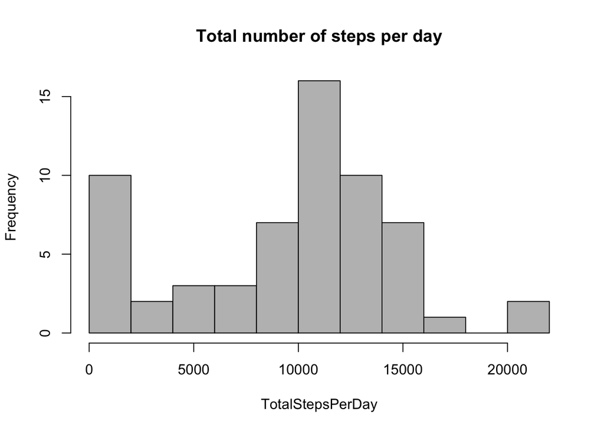

```r
# histogram of the total number of steps taken each day
with(dailyTotalSteps, hist(TotalStepsPerDay, breaks=8, main="Total number of steps per day", col="grey"))
```

```r
# Mean and Median for  total number of steps taken per day
meands <- mean(dailyTotalSteps$TotalStepsPerDay, na.rm = TRUE)
mediands <- median(dailyTotalSteps$TotalStepsPerDay, na.rm = TRUE)
```

### 3. What is the average daily activity pattern?

```r
# average number of steps taken, averaged across all days (y-axis)
by_interval <- group_by(ActivityData, interval)
IntervalAvgSteps <- summarize(by_interval, Steps = mean(steps, na.rm=TRUE))
```

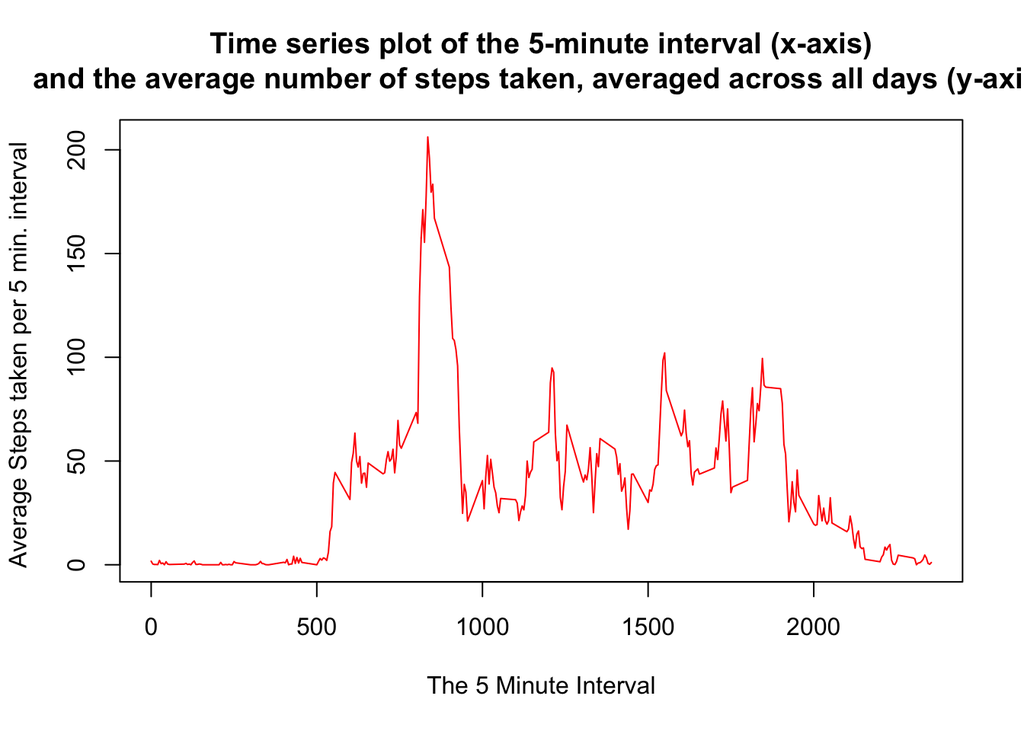

```r
#Here is a time series plot of the 5-minute interval (x-axis) and the average number of steps taken, averaged across all days (y-axis)
with(IntervalAvgSteps, plot(interval, Steps, type="l", col="red", xlab = "The 5 Minute Interval", ylab= "Average Steps taken per 5 min. interval "))

title(main="Time series plot of the 5-minute interval (x-axis)
and the average number of steps taken, averaged across all days (y-axis)"
)
```

```r
max <- with(IntervalAvgSteps, interval[which.max(Steps)])
```

835th, 5-minute interval, on average across all the days in the dataset, contains the maximum number of steps

### 4. Imputing Missing Values

There are a number of days/intervals where there are missing values (coded as NA NA).  
The presence of missing days may introduce bias into some calculations or summaries of the data.

```r
table(is.na(ActivityData$steps))
```

```
##
## FALSE  TRUE
## 15264  2304
```

```r
sumNA <- sum(is.na(ActivityData$steps))
```

Total number of missing values in the dataset 2304

We will use mean for that 5-minute interval to fill in the missing values in the dataset. Here is 4 Step process for filling in the missing values in steps variable

```r
# Merging Original Data with another datafram to add column having average number of steps per 5 minute interval
mrg <- merge.data.frame(ActivityData, IntervalAvgSteps)
# finding Position Vector of Missing Values (NAs)
NAv <- which(is.na(ActivityData$steps))
# Mutating steps value with average steps per 5 min stored in Steps Variable
mrg[NAv, 2 ] <- mrg$Steps[which(is.na(mrg$steps))]
# Select Only Required Variables
mrg <- select(mrg, steps, date, interval)
# Arranging the data by date
ActivityData2 <- arrange(mrg, date)
```

```r
# Calculate Total Number of Steps Per Day (Date)
dailyTotalSteps2<-ddply(mrg, "date", summarise, TotalStepsPerDay = sum(steps, na.rm = TRUE))
```

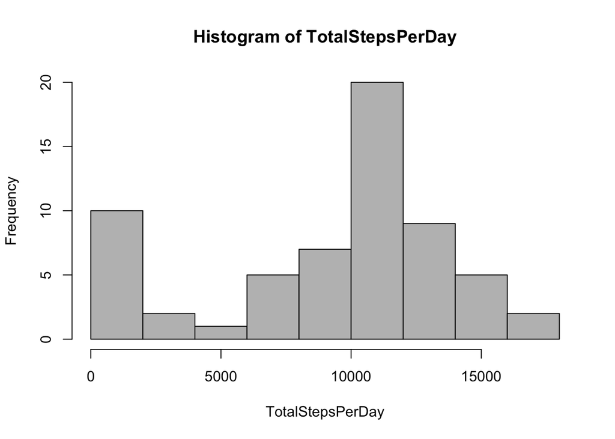

```r
# plot the histogram of the total number of steps taken each day
with(dailyTotalSteps2, hist(TotalStepsPerDay, col="grey"))
```

```r
avg <- mean(dailyTotalSteps2$TotalStepsPerDay, na.rm = TRUE)
med <- median(dailyTotalSteps2$TotalStepsPerDay, na.rm = TRUE)
```

### 5. Are there differences in activity patterns between weekdays and weekends?

Create a new factor variable in the dataset with two levels, weekday and weekend indicating whether a given date is a weekday or weekend day.

```r
# Adding helper Variable weekday for given variable date
ActivityData2$weekday <- wday(ActivityData2$date, label = TRUE)
# Instantating factor Variable with two level , weekday and weekend
ActivityData2$wdayType<-c(1)
ActivityData2$wdayType[which(ActivityData2$weekday %in% c('Sat', 'Sun'))] <-'Weekend'
ActivityData2$wdayType[which(!(ActivityData2$weekday %in% c('Sat', 'Sun')))] <-'Weekday'
```

```r
by_interval_wdayType <- group_by(ActivityData2, interval,wdayType)
interval_wdayType <- summarize(by_interval_wdayType, steps =mean(steps, na.rm = TRUE))
```

Panel plot containing a time series plot of the 5-minute interval (x-axis) and the average number of steps taken, averaged across all weekday days or weekend days (y-axis).

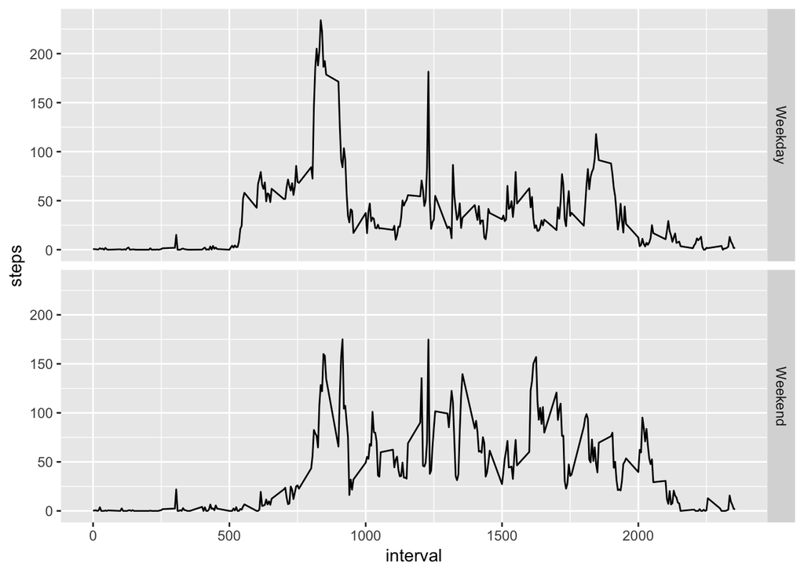

```r
qplot(interval, steps, data = interval_wdayType, facets = wdayType~., geom="line")
```